# TALLER No.1: CRÍTICA VISUALIZACIÓN DE DATOS

## Visualización 1:

### La marcha del coronavirus por América

Contexto: El 22 de febrero, Biden marcó 500.000 muertes oficiales a causa de la enfermedad al observar una ceremonia de encendido de velas fuera de la Casa Blanca mientras las campanas de la Catedral Nacional sonaban 500 veces.

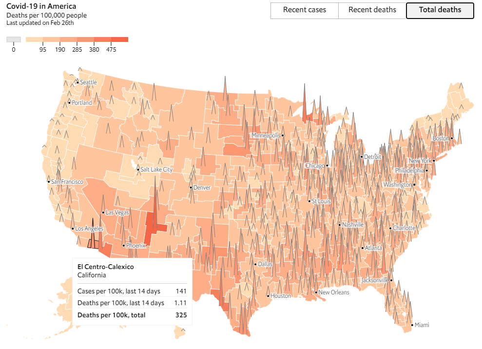

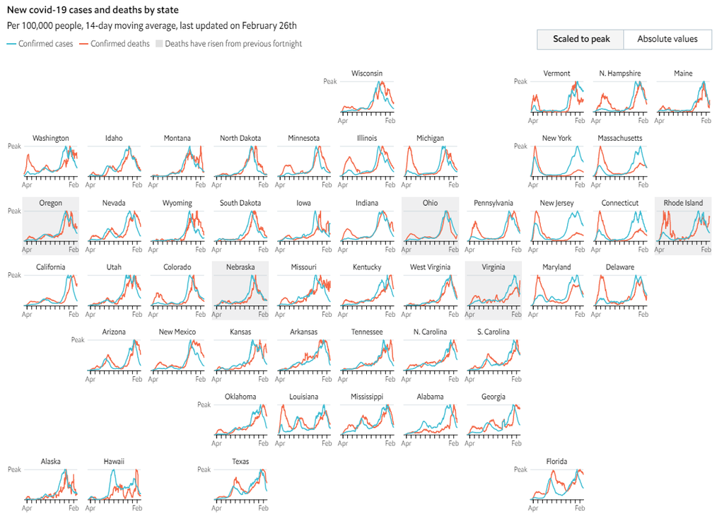

En estas visualizaciones anteriores se presenta otra forma de visualizar la pandemia en Estados Unidos. Muestran promedios móviles de 14 días de casos y muertes para los 50 estados. Los datos pueden verse como un índice (con el pico en cada estado establecido en 100) o por cada 100,000 personas. El gráfico muestra que el brote de covid-19 se limitó principalmente a los estados del noreste en abril y mayo, pero ahora está causando estragos en casi todas partes.

1. *¿Que?, ¿por qué? y ¿cómo?*
- *¿Qué?*

- *¿Por qué?*

En particular se quiere visualizar el comportamiento geográfico, toda vez que en esta visualización observamos en que en algunos lugares del país hay mayor cantidad de contagios y de muertes, adicionalmente, está visualización busca presentar como se distribuyeron los casos dentro de los Estados Unidos.

- *¿Como?**

1. *Marcas y Canales utilizados*
- *Marca:* Para el presente caso la marca es el area geografica y lineas de densidad.
- *Canal:* El color es canal especifico para esta visualización,toda vez que nos permite distinguir de un area geográfica a otra que estado obtuvo mas contagios y numero de muertes.
1. *¿Cumple o no cumplealguna de las regas establecidas?*

Si cumple, ya que no utiliza de forma inecesariamente recursos, por otra parte por medio de la navegación en una sola vista se pueden comparar zonas geográficas y si se quiere ver a detalle de alguna estado en especifico basta con poner el cursor sobre este para que la información se despliegue.

1. *Mejoras posibles, en cuánto a marcas o canales, que le realizaría a la visualización*

En mi opinión no tendria mejoras en cuanto a masrcas o canales pero si seria bueno poder hacer una sola visualización de la segunda imagen que pueda agrupar todos los estados y se desglocen dichos al indicar el estado con el cursor.

### *Fuente*

Centres for Disease Control and Prevention; Johns Hopkins University CSSE; New York Times; US Census Bureau; The Economist (https://www.economist.com/graphic-detail/tracking-coronavirus-across-america)

## Visualización 2:

### Niveles de estrés hídrico global

Contexto: Se muestran las ciudades más grandes del mundo en riesgo de quedarse sin agua.

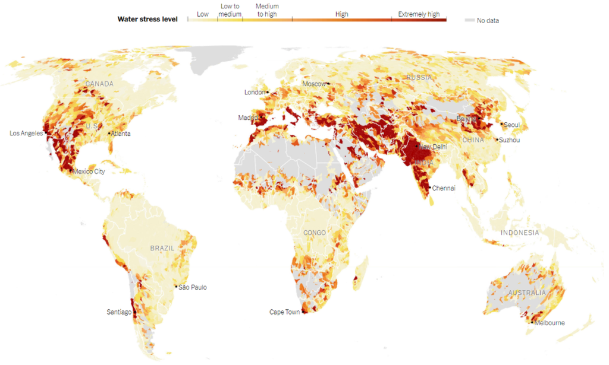

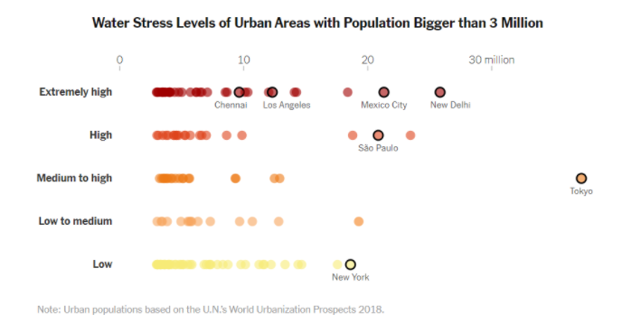

1. *¿Que?, ¿por qué? y ¿cómo?*
- *¿Que?*

Se tienenlos datos de los niveles de estrés hídrico en todo el mundo aparecieron en otra parte de NYTimes.com, en esto sabemos que tenemos la base de datos con datos categoricos ordenados (ubicación geográfica) y tenemos el número de los niveles de estres obtenidos .

- *¿Por que?*

En particular se quiere visualizar el comportamiento geográfico, toda vez que en esta visualización observamos en que ciudades del mundo tuvo mayores niveles de estres hidrico, está visualización busca presentar como se distribuyeron los niveles dentro de las ciudades mas grandes del mundo.

1. *Marcas y Canales utilizados*
- *Marcas:* La marca utilizada en este caso es el area geográfica y puntos.
- *Canales:*El canal para está visualización es el color y la forma.
1. *Cumple o no cumple alguna de las reglas generales descritas*

Si cumple, ya que no utiliza de forma inecesariamente recursos.

4.*Mejoras posibles, en cuánto a marcas o canales, que le realizaría a la visualización*

Dentro de mi punto de vista seria bueno que se manera una visualización con la primera donde se pueda seleccionar un ciudad y se pueda reflejar desplegado o de forma mas amplia los niveles de dicha.

### Fuente

The New York Times,Global Water Stress Levels recuperado(https://www.nytimes.com/2020/01/16/learning/whats-going-on-in-this-graph-global-water-stress-levels.html)